# FitBit Activity data Analysis

24th April

### Description

This is the first project of Reproducible Research course in Coursera’s Data Science Specialization. This project deals with answering a series of questions by analysing an anonymous Fitbit data.

## Data

The data for this assignment can be downloaded from the course web site:

- Dataset: Activity monitoring data [52K]

The variables included in this dataset are:

- **steps**: Number of steps taking in a 5-minute interval (missing values are coded as `NA`)
- **date**: The date on which the measurement was taken in YYYY-MM-DD format
- **interval**: Identifier for the 5-minute interval in which measurement was taken

The dataset is stored in a comma-separated-value (CSV) file and there are a total of 17,568 observations in this dataset.

## Loading and preprocessing the data

The repo has been forked, downloaded to github desktop and used for analysis unzip the file `activity.zip` and load it into a dataframe `data`

```r
data<-read.csv("activity/activity.csv")
```

## What is mean total number of steps taken per day?

Sum total number of steps by day (date), create a histogram, calculate mean and median

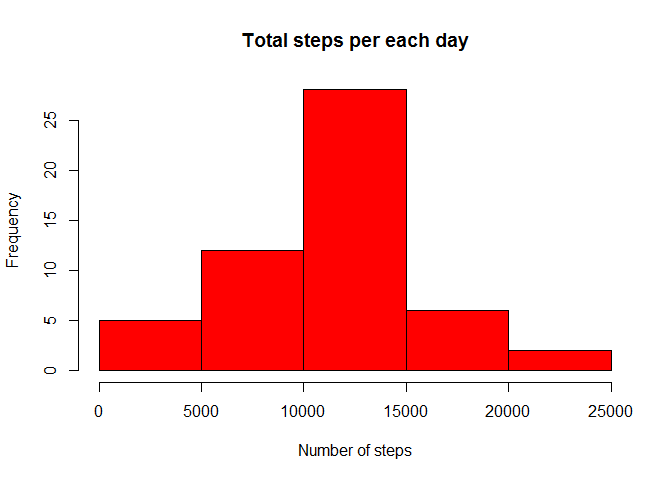

```r
steps_eachday<-aggregate(steps~date,data,sum)
hist(steps_eachday$steps,main = "Total steps per each day", col = "red", xlab = "Number of steps")
```

```r
steps_mean<-mean(steps_eachday$steps)
steps_median<-median(steps_eachday$steps)
```

The mean thus obtained is `steps_mean` = 10766.188, median is `steps_median` = 10765

## What is the average daily activity pattern?

- Calculate Average number of steps for each interval for each day
- Plot the Average Number Steps per Day by Interval into a time series plot.
- Find interval with most average steps.

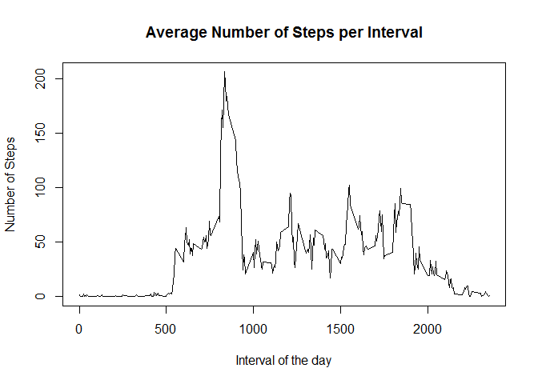

```r
steps_eachinterval <- aggregate(steps ~ interval, data, mean)
plot(steps_eachinterval$interval,steps_eachinterval$steps, type="l", xlab="Interval of the day", ylab="Number of Steps",main="Average Number of Steps per Interval")
```

```r
max_steps<-steps_eachinterval[which.max(steps_eachinterval$steps),1]
```

The 5-minute interval containing the maximum number of steps in the data is 835.

## Impute missing values. Compare imputed to non-imputed data.

Missing data (NA) needed to be imputed. Missing values were imputed by inserting the average for each interval.

```r
noofNAs<- sum(!complete.cases(data))
rearranged_data <- transform(data, steps = ifelse(is.na(data$steps), steps_eachinterval$steps[match(data$interval, steps_eachinterval$interval)], data$steps))
```

```r
rearranged_data[as.character(rearranged_data$date) == "2012-10-01", 1] <- 0
```

Recount total steps by day and create Histogram.

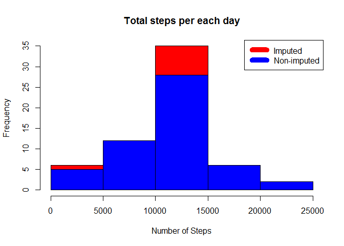

```r
steps_eachday_re <- aggregate(steps ~ date, rearranged_data, sum)
hist(steps_eachday_re$steps, main = paste("Total steps per each day"), col="red", xlab="Number of Steps")

#difference histogram
hist(steps_eachday$steps, main = paste("Total steps per each day"), col="blue", xlab="Number of Steps", add=T)
legend("topright", c("Imputed", "Non-imputed"), col=c("red", "blue"), lwd=10)
```

Calculate new mean and median for imputed data.

```r
steps_mean_re <- mean(steps_eachday_re$steps)
steps_median_re <- median(steps_eachday_re$steps)
```

Calculate difference between imputed and non-imputed data.

```r
mean_difference <- steps_mean_re - steps_mean
median_difference <- steps_median_re - steps_median
```

Calculate total difference.

```r
total_difference_steps <- sum(steps_eachday_re$steps) - sum(steps_eachday$steps)
```

## Are there differences in activity patterns between weekdays and weekends?

Created a plot to compare and contrast number of steps between the week and weekend. There is a higher peak earlier on weekdays, and more overall activity on weekends.

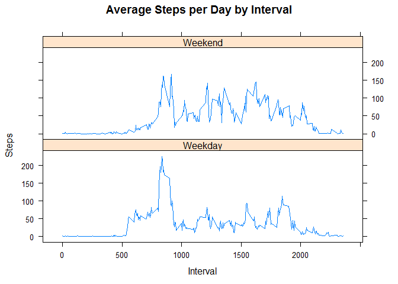

```r
library(lattice)
weekdays <- c("Monday", "Tuesday", "Wednesday", "Thursday",
              "Friday")
rearranged_data$dayclassify = as.factor(ifelse(is.element(weekdays(as.Date(rearranged_data$date)),weekdays), "Weekday", "Weekend"))

steps_eachinterval_re <- aggregate(steps ~ interval + dayclassify, rearranged_data, mean)

xyplot(steps_eachinterval_re$steps ~ steps_eachinterval_re$interval|steps_eachinterval_re$dayclassify, main="Average Steps per Day by Interval",xlab="Interval", ylab="Steps",layout=c(1,2), type="l")
```